# Lab4Reesa

Reesa John

February 16, 2019

```r
library(tidyverse)
```

```r
library(broom)
library(ggplot2)
pokes <- read.csv("https://www.dropbox.com/s/i0lwxgv86eaoq4o/pokemon.csv?dl=1",na.strings = "")

pokes <-pokes %>%
  mutate(Generation = as.factor(Generation))
```

What makes a pokemon a good fighter? From playing pokemon, ignoring using pokemon as support, I would say it should have either a great offense or defense. However, there are a few who tend to excel in all fields.

I have decided to explore which pokemon tend to have the best offense, defense, and overall stats. I will gather the top ten in each category.

I already know from experience that a pokemon’s number, height, and weight are irrevelant. Catch rate is important to know the feasibility of acquiring pokemon, but for the sake of having a condensed report, I will ignore that as well.

In addition to finding the top ten in offense, defense, and overall stats, I will see if there is a type that tends to do better in any of these three categories.

To start, I decided to get an overview of the data using str() and summary().

```r
str(pokes)
```

```
## 'data.frame':    721 obs. of  15 variables:
##  $ Number    : int  1 2 3 4 5 6 7 8 9 10 ...
##  $ Name      : Factor w/ 721 levels "Abomasnow","Abra",..: 68 295 670 87 88 86 595 688 54 82 ...
##  $ Type_1    : Factor w/ 18 levels "Bug","Dark","Dragon",..: 10 10 10 7 7 7 18 18 18 1 ...
##  $ Type_2    : Factor w/ 18 levels "Bug","Dark","Dragon",..: 14 14 14 NA NA 8 NA NA NA NA ...
##  $ Total     : int  318 405 525 309 405 534 314 405 530 195 ...
##  $ HP        : int  45 60 80 39 58 78 44 59 79 45 ...
##  $ Attack    : int  49 62 82 52 64 84 48 63 83 30 ...
##  $ Defense   : int  49 63 83 43 58 78 65 80 100 35 ...
##  $ Sp_Atk    : int  65 80 100 60 80 109 50 65 85 20 ...
##  $ Sp_Def    : int  65 80 100 50 65 85 64 80 105 20 ...
##  $ Speed     : int  45 60 80 65 80 100 43 58 78 45 ...
##  $ Generation: Factor w/ 6 levels "1","2","3","4",..: 1 1 1 1 1 1 1 1 1 1 ...
##  $ Height_m  : num  0.71 0.99 2.01 0.61 1.09 1.7 0.51 0.99 1.6 0.3 ...
##  $ Weight_kg : num  6.9 13 100 8.5 19 90.5 9 22.5 85.5 2.9 ...
##  $ Catch_Rate: int  45 45 45 45 45 45 45 45 45 255 ...
```

```r
summary(pokes)
```

```
##      Number            Name         Type_1         Type_2
##  Min.   :  1   Abomasnow :  1   Water  :105   Flying  : 87
##  1st Qu.:181   Abra      :  1   Normal : 93   Poison  : 31
##  Median :361   Absol     :  1   Grass  : 66   Ground  : 30
##  Mean   :361   Accelgor  :  1   Bug    : 63   Psychic : 27
##  3rd Qu.:541   Aegislash :  1   Fire   : 47   Fighting: 19
##  Max.   :721   Aerodactyl:  1   Psychic: 47   (Other) :156
##                (Other)   :715   (Other):300   NA's    :371
##      Total             HP             Attack          Defense
##  Min.   :180.0   Min.   :  1.00   Min.   :  5.00   Min.   :  5.00
##  1st Qu.:320.0   1st Qu.: 50.00   1st Qu.: 53.00   1st Qu.: 50.00
##  Median :424.0   Median : 65.00   Median : 74.00   Median : 65.00
##  Mean   :417.9   Mean   : 68.38   Mean   : 75.01   Mean   : 70.81
##  3rd Qu.:499.0   3rd Qu.: 80.00   3rd Qu.: 95.00   3rd Qu.: 85.00
##  Max.   :720.0   Max.   :255.00   Max.   :165.00   Max.   :230.00
##
##      Sp_Atk           Sp_Def           Speed        Generation
##  Min.   : 10.00   Min.   : 20.00   Min.   :  5.00   1:151
##  1st Qu.: 45.00   1st Qu.: 50.00   1st Qu.: 45.00   2:100
##  Median : 65.00   Median : 65.00   Median : 65.00   3:135
##  Mean   : 68.74   Mean   : 69.29   Mean   : 65.71   4:107
##  3rd Qu.: 90.00   3rd Qu.: 85.00   3rd Qu.: 85.00   5:156
##  Max.   :154.00   Max.   :230.00   Max.   :160.00   6: 72
##
##     Height_m        Weight_kg        Catch_Rate
##  Min.   : 0.100   Min.   :  0.10   Min.   :  3.0
##  1st Qu.: 0.610   1st Qu.:  9.40   1st Qu.: 45.0
##  Median : 0.990   Median : 28.00   Median : 65.0
##  Mean   : 1.145   Mean   : 56.77   Mean   :100.2
##  3rd Qu.: 1.400   3rd Qu.: 61.00   3rd Qu.:180.0
##  Max.   :14.500   Max.   :950.00   Max.   :255.0
##
```

In general, if a pokemon is better offensively, they tend to have great Attack, Special Attack, and Speed, and if they are better defensively, they tend to have great Defense, Special Defense, and HP. So in order to figure out which pokemon are better in each category, I need to create two variables Atk_Score and Def_Score which give more weight to certain fighting qualities over the other depending on what I’m measuring for.

I also need to know if there is a relationship between Attack and Special Attack, as well as Defense and Special Defense to properly weight these in their own categories. I made two new variables, diff_atks(the difference between Attack and Special Attack) and dif_defs(the difference between Defense and Special Defense) and conducted a linear regression t-test on Attack vs diff_atks and Defense vs diff_defs.

If it had a positive slope, that means the higher in value attack or defense is, the lower in value their special counterparts would be compared to their attack or defense and vice versa. Looking at the results of the linear regressions, both slopes are positive, and their p-values are well under 0.01, which means the results are not by chance, so it would be reasonable to assume that a higher attack or defense results in lower values for their special counterparts.

```r
lm_pokes <-pokes %>%
  mutate(diff_atks = (Attack-Sp_Atk),
         diff_defs = (Defense-Sp_Def))

tidy(lm( Attack ~ diff_atks, data = lm_pokes))
```

```
## # A tibble: 2 x 5
##   term        estimate std.error statistic  p.value
##   <chr>          <dbl>     <dbl>     <dbl>    <dbl>
## 1 (Intercept)   71.8      0.895       80.3 0.
## 2 diff_atks      0.505    0.0264      19.1 3.59e-66
```

```r
tidy(lm(Defense ~ diff_defs, data = lm_pokes))
```

```
## # A tibble: 2 x 5
##   term        estimate std.error statistic  p.value
##   <chr>          <dbl>     <dbl>     <dbl>    <dbl>
## 1 (Intercept)   69.9      0.902       77.6 0.
## 2 diff_defs      0.578    0.0314      18.4 3.04e-62
```

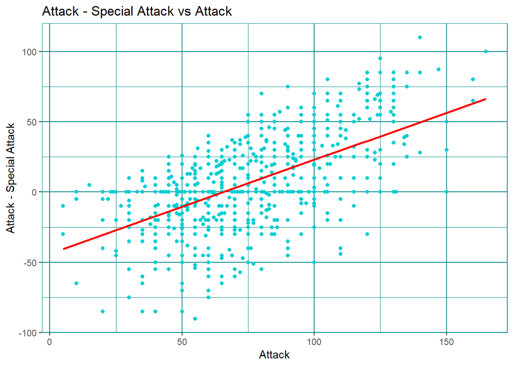

```r
lm_pokes %>% ggplot(aes(x=Attack,y=diff_atks))+geom_point(color = "darkturquoise")+
  geom_smooth(method = lm, color = "red", alpha = 0)+
  ylab("Attack - Special Attack")+ theme(
  panel.background = element_rect(fill = "white",
                                colour = "turquoise4",
                                size = 0.5, linetype = "solid"),
  panel.grid.major = element_line(size = 0.5, linetype = 'solid',
                                colour = "turquoise4"),
  panel.grid.minor = element_line(size = 0.25, linetype = 'solid',
                                colour = "turquoise4") )+
  ggtitle("Attack - Special Attack vs Attack")
```

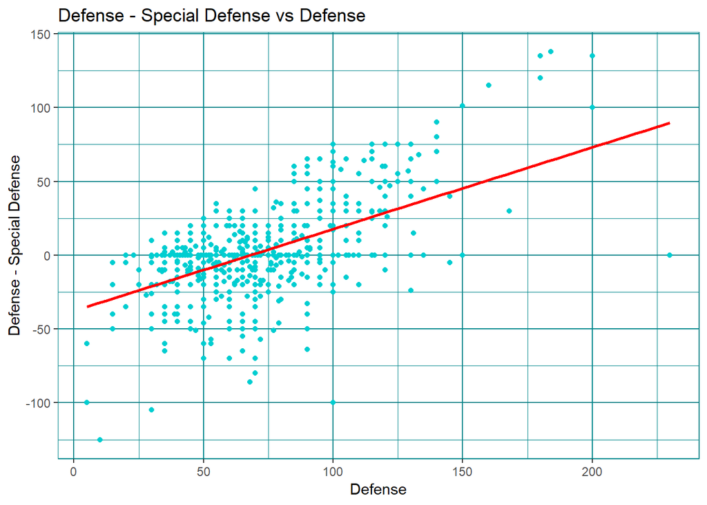

```r
lm_pokes %>% ggplot(aes(x=Defense,y=diff_defs))+geom_point(color = "darkturquoise")+
  geom_smooth(method = lm, color = "red", alpha = 0)+
  ylab("Defense - Special Defense")+ theme(
  panel.background = element_rect(fill = "white",
                                colour = "turquoise4",
                                size = 0.5, linetype = "solid"),
  panel.grid.major = element_line(size = 0.5, linetype = 'solid',
                                colour = "turquoise4"),
  panel.grid.minor = element_line(size = 0.25, linetype = 'solid',
                                colour = "turquoise4") )+
  ggtitle("Defense - Special Defense vs Defense")
```

Now to create Atk_Score, and Def_Score, I have come up with two formulas:

```r
pokes <- pokes %>% mutate(
    Atk_Score = (0.75*(HP+ Defense+Sp_Def))+(1.5*pmin(Sp_Atk,Attack))+(2*(pmax(Sp_Atk,Attack)+Speed)),
    Def_Score = (0.75*(Speed+pmin(Sp_Atk,Attack)))+(1.25*pmax(Sp_Atk,Attack))+(2*(Sp_Def+Defense+HP))
    )
```

In the case of attack, you can choose more special or non-special moves to give to you pokemon depending on which type of attack it is more proficient in, so I made a point to give more weight to the higher one. I also put less weight on HP, Defense, and Sp_Def because if you are going for a pokemon that prioritizes attacking, you ideally want it to defeat your opponent before it can hit you.

I have chosen to give the same weight to both Defense and Special Defense despite the results, since it’s more important to defend from all sorts of attacks. I also decided to give more weight to the better of its two attacks and less weight to the rest of its stats as it does need to ultimately defeat its opponent, but doesn’t need to be exceptionally strong to do that.

I have also used the variable total as my measurement for overall stats, as it is the aggregate of all fighting qualities.

```r
pokes %>%
  select(Name, Total, HP, Attack, Defense, Sp_Atk, Sp_Def, Speed, Atk_Score)%>%
  top_n(n=10, wt=Atk_Score)%>%
  arrange(desc(Atk_Score))
```

```
##        Name Total  HP Attack Defense Sp_Atk Sp_Def Speed Atk_Score
## 1    Mewtwo   680 106    110      90    154     90   130    947.50
## 2    Deoxys   600  50    150      50    150     50   150    937.50
## 3    Arceus   720 120    120     120    120    120   120    930.00
## 4  Rayquaza   680 105    150      90    150     90    95    928.75
## 5    Palkia   680  90    120     100    150    120   100    912.50
## 6    Dialga   680 100    120     120    150    100    90    900.00
## 7  Reshiram   680 100    120     100    150    120    90    900.00
## 8    Zekrom   680 100    150     120    120    100    90    900.00
## 9   Slaking   670 150    160     100     95     65   100    898.75
## 10  Xerneas   680 126    131      95    131     98    99    895.75
## 11  Yveltal   680 126    131      95    131     98    99    895.75
```

```r
pokes %>%
  select(Name, Total, HP, Attack, Defense, Sp_Atk, Sp_Def, Speed, Def_Score)%>%
  top_n(n=10, wt=Def_Score)%>%
  arrange(desc(Def_Score))
```

```
##         Name Total  HP Attack Defense Sp_Atk Sp_Def Speed Def_Score
## 1     Arceus   720 120    120     120    120    120   120    1050.0
## 2      Lugia   680 106     90     130     90    154   110    1042.5
## 3      Ho-Oh   680 106    130      90    110    154    90    1012.5
## 4   Giratina   680 150    120     100    120    100    90    1007.5
## 5  Regigigas   670 110    160     110     80    110   100     995.0
## 6     Kyogre   670 100    100      90    150    140    90     990.0
## 7    Groudon   670 100    150     140    100     90    90     990.0
## 8     Dialga   680 100    120     120    150    100    90     985.0
## 9   Reshiram   680 100    120     100    150    120    90     985.0
## 10    Zekrom   680 100    150     120    120    100    90     985.0
```

```r
pokes %>%
  select(Name, Total, HP, Attack, Defense, Sp_Atk, Sp_Def, Speed)%>%
  top_n(n=10, wt=Total)%>%
  arrange(desc(Total))
```

```
##        Name Total  HP Attack Defense Sp_Atk Sp_Def Speed
## 1    Arceus   720 120    120     120    120    120   120
## 2    Mewtwo   680 106    110      90    154     90   130
## 3     Lugia   680 106     90     130     90    154   110
## 4     Ho-Oh   680 106    130      90    110    154    90
## 5  Rayquaza   680 105    150      90    150     90    95
## 6    Dialga   680 100    120     120    150    100    90
## 7    Palkia   680  90    120     100    150    120   100
## 8  Giratina   680 150    120     100    120    100    90
## 9  Reshiram   680 100    120     100    150    120    90
## 10   Zekrom   680 100    150     120    120    100    90
## 11  Xerneas   680 126    131      95    131     98    99
## 12  Yveltal   680 126    131      95    131     98    99
```

Unsurprisingly there is a fair amount of overlap between the three top tens, with Arceus reigning supreme in both defense and overall, and Mewtwo ranking the best offensively.

Now I am going to see if pokemon tend to be stronger in either offense, defense, or overall stats if they are of a certain type. To simplify things, I have decided condense Type_1 and Type_2 to a single column, and eliminate any rows in that have NA in type.

```r
pokes1 <- pokes %>%
  select(-Type_2)%>%
  rename(Type = Type_1)

pokes2 <- pokes %>%
  select(-Type_1)%>%
  rename(Type = Type_2)

ggpokes <- rbind(pokes1, pokes2)%>%
  arrange(Number)%>%
  filter(!is.na(Type))
```

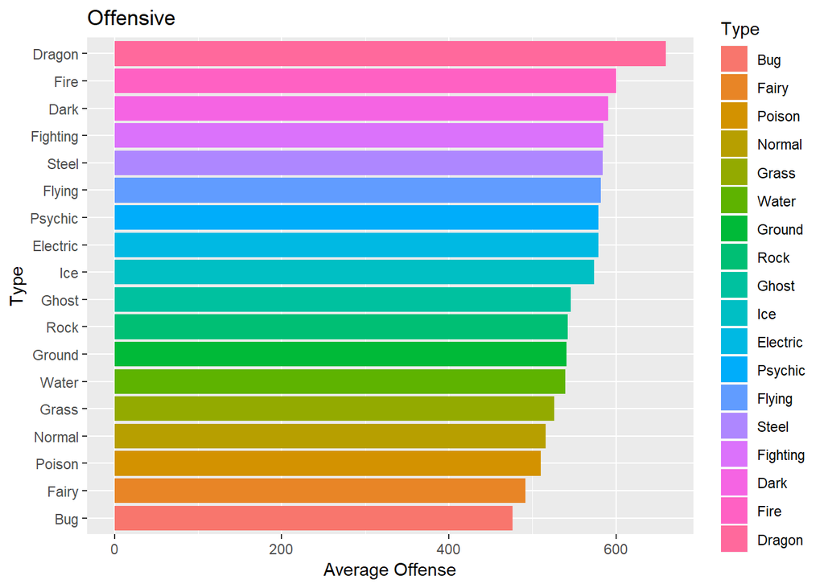

```r
ggpokes <- ggpokes %>%
  group_by(Type) %>%
  summarize(Avg_Offense = mean(Atk_Score),
            Avg_Defense = mean(Def_Score),
            Avg_Total = mean(Total))

ggpokes %>%
  mutate( Type = fct_reorder(Type, Avg_Offense)) %>%
  ggplot(aes(x=Type ,y= Avg_Offense, fill = Type))+geom_col() + coord_flip()+ggtitle("Offensive") +
  ylab("Average Offense")
```

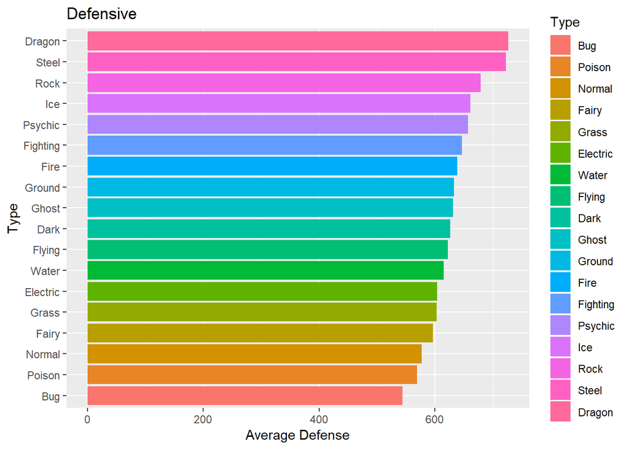

```r
ggpokes %>%
  mutate( Type = fct_reorder(Type, Avg_Defense)) %>%
  ggplot(aes(x=Type ,y= Avg_Defense, fill = Type))+geom_col() + coord_flip()+ggtitle("Defensive")+
    ylab("Average Defense")
```

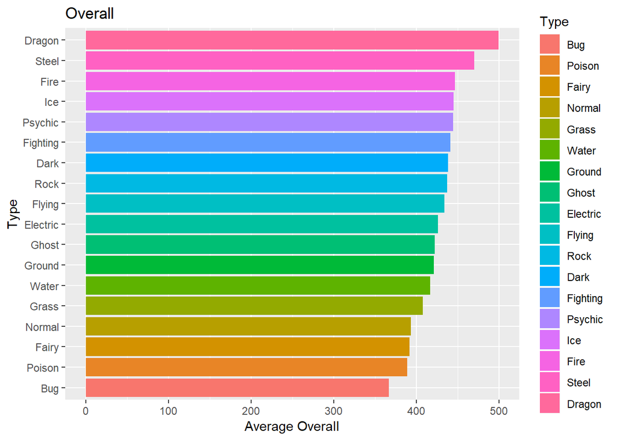

```r
ggpokes %>%
  mutate( Type = fct_reorder(Type, Avg_Total)) %>%
  ggplot(aes(x=Type ,y= Avg_Total, fill = Type))+geom_col() + coord_flip()+ggtitle("Overall")+
    ylab("Average Overall")
```